# Example .Rmd for plot about xyz

2024-07-14

# **Recommedation 1**

Code your plot in a .R file and then call that into your .Rmd file.

## **Read .png graphic into the .Rmd file**

This is what you will do for the team project.

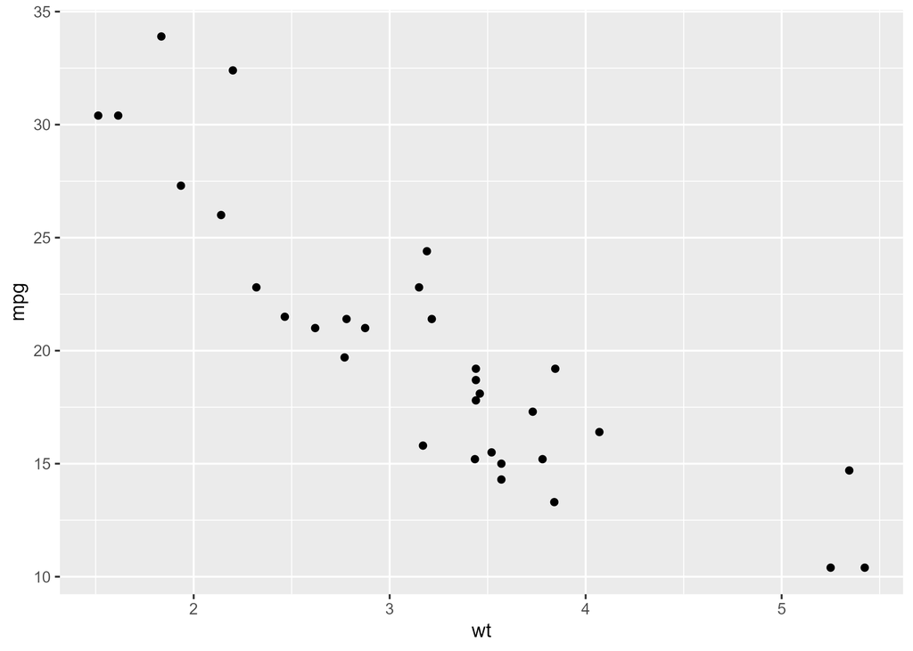

# **Recommendation 2**

Another approach is to work in the .Rmd file. Once you are happy with it, make a copy that removes the Markdown code and save as a .R script.

```r
################################################################################
# ggplot2 code for creating visualization about ...

mtcars_plot <-
  dat |>
  ggplot() +
  geom_point(mapping = aes(x = wt, y = mpg))


################################################################################
# code to save plot

ggsave(filename = here::here("report", "figs", "my_awesome_plot.png"),
       plot = mtcars_plot,  # last_plot(),  the default is the last plot
       device = ragg::agg_png,
       dpi = 320            # 320 retina, 300 is fine
)
```

# **Note**

However you decide to create your scripts, you will:

1. add your author name;
2. provide a description about its purpose;
3. ensure you load function files and libraries;
4. using **{here}**, save the plot as a .png file in /report/figs;
- **Ex:** here::here(“report”, “figs”, “my_awesome_plot.png”),
5. save the script in /src/figs making sure to name it and the .png file with same name, meaningful for the plot. Don’t name the plot something like Plot42;
- **Ex:** here::here(“src”, “figs”, “my_awesome_plot.R”),
6. and then using **{here}**, source the script from /src/figs in your .Rmd report file if its needed
- **Ex:** source(here::here(“src”, “figs”, “my_awesome_plot.R”))